# ETC5521 Assignment 1

Fines or Taxes? Exploratory Data Analysis on General Data Protection Regulation Fines

(Weihao Li)

(Dang Thanh Nguyen)

Brenwin Ang

Muhammad Soban Qasim

2020-09-19

This assignment is for ETC5521 Assignment 1 by Team cassowary comprising of (Weihao Li), (Dang Thanh Nguyen), Brenwin Ang, and Muhammad Soban Qasim.

[figure not shown]

Figure 0.1: GDPR logo (Source: Training Journal (2018))

# 1 Introduction and motivation

General Data Protection Regulation (GDPR) is a regulation that came into effect on 25 May 2018. GDPR aims to “protect fundamental rights and freedoms of natural persons and in particular their right to the protection of personal data” (Regulation, 2016). GDPR imposes obligations onto organisations anywhere, so long they target or collect data related to people in EU.

Due to its novelty in establishment, Tikkinen-Piri, Rohunen, & Markkula (2018) stated that it would be a challenge to companies who lack awareness of the GDPR’s practical implications. Inconsistent practical and technical implementation of GDPR in organisation dealings in EU could be anticipated. By August 2020, more than 49 companies have been fined at least 100 thousand euros. Most of these fines were issued to IT companies (CoreView, 2020). The most famous (& largest) of these is was the 50 million euros fine issued to Google in France lack of transparency in data consent policies. (Porter (2020))

Meanwhile, Lewis, Conleya, & Lee-Makiyama (2020) suggests that GDPR poses a political challenge in Europe’s battle to its digital future - A balance had to be striked between overregulation and risk-taking entrepreneurship; which has implications on the economy. Besides, part of the reasons behind the GDPR establishment and the later digital services taxes imposed by major EU countries were an indication that EU was waving the flag of digital sovereignty. Thus, against digital hegemony, it may have unintentionally placed a bottleneck especially on IT companies.

Available data of GDPR fines from Privacy Affairs (2020), allows for gaining insight into the privacy issues and examine any trends in violation of articles of GDPR. This dataset was originally adopted by Tidy Tuesday (2020), which is a social weekly data project in R. [[github](https://github.com/rfordatascience/tidytuesday/blob/master/data/2020/2020-04-21/readme.md)] We outline the workflow of data collection, data cleaning and data analysis in the following sections.

# 2 Limitations

A potential limitation of this research is a good proportion(about 10%) of controller names (violators) are missing from the data set which introduces extra difficulties to draw accurate conclusions with respect to the company nationality and identity.

Fines documented by Privacy Affairs (2020) pertains to fines made public hence many of the fines may not be present. This data set can be thought of as “high-profile” fines.

# 3 Data description

The data was scraped from Privacy Affairs (2020) by Ellis Hughes (2020), which posted on Tidy Tuesday (2020) github repo. We slightly adapted the scripts and removed duplication of GDPR fines due to multiple sources. Data spans from 2018-05-12 to 2020-08-21.

Abnormal values includes fines with 0 price, indicating ongoing trials and fines before the establishment of the GDPR (which are implausible values) are set NA. Records with missing date are also set to NA. We further process inconsistency in corporation names. There are a number of unnamed organizations fined by GDPR in the data set. These are labelled as “Unknown”.

The dataset has some limitations that can be identified by the (source Privacy Affairs (2020))  
- Not all cases are presented in the dataset. The data only includes finalised cases and cases that are made public. This can lead to bias in further analysis. - A number of controller(violators) are vaguely described, or not disclosed. This may lead to misunderstanding and bias in the analysis.

The data consist of two datasets:

1. `GDPR_Violations.tsv` contains information of 347 fines/penalties which data protection authorities (in EU) have imposed under GDPR. Variables includes the country(where violation enforced), authority, date of violation, fine price of violation in Euros(€).
2. `GDPR_text.tsv` contains articles of GDPR (99 of them). Included are Chapter title, article number, artcile title and raw text of the article.

Each variable are detailed in next the Section (3.1).

## 3.1 Data Dictionary

### 3.1.1 `gdpr_violations.tsv`

| variable | class | description |
| --- | --- | --- |
| id | integer | Idetifier for fine/violation |
| picture | character | SVG image of violation country flag |
| name | character | Name of country where violation was enforced |
| price | integer | Fine price in Euros (€) |
| authority | character | Authority that enacted the violation |
| date | character | Date of violation |
| controller | character | Controller of data - the violator |
| article_violated | character | Specific GDPR Article violated (see the `gdpr_text.tsv` data for specifics) |
| type | character | Type of violation |
| source | character | Original source (URL) of fine data |
| summary | character | Summary of violation |

### 3.1.2 `gdpr_text.tsv`

| variable | class | description |
| --- | --- | --- |
| chapter | double | GDPR Chapter Number |
| chapter_title | character | Chapter title |
| article | double | GDPR Article number |
| article_title | character | Article title |
| sub_article | double | Sub article number |
| gdpr_text | character | Raw text of article/subarticle |
| href | character | URL to the raw text itself |

## 3.2 Research questions

The overall aim of this research is to examine the demographics in the application of the GDPR in practice since its implementation (in 25 May 2018) and unveil any prevalent privacy issues in EU’s cyberspace.

Three secondary questions are addressed in this research:

1. What were the characteristics of GDPR fines across countries, time and corporations? Are certain corporations targets of GDPR authorities?
2. Which articles and regulations were more likely to be violated? And how much they commonly charged?
3. What were the key words in each article, especially articles referenced the most in GDPR fines? Does this mean anything such as particular privacy issues?

# 4 Analysis and findings

## 4.1 GDP violations across time since its implementation

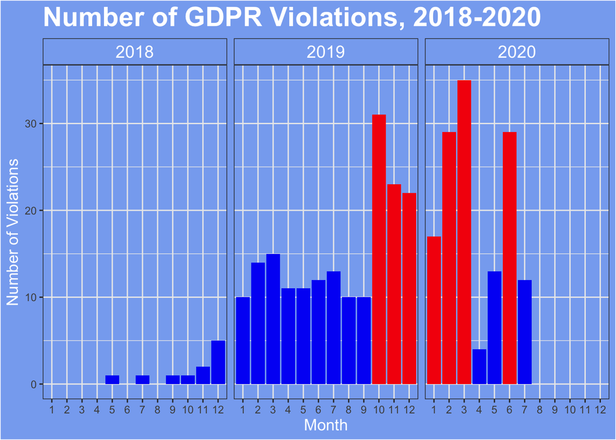

Figure 4.1: Monthly number of GDPR violations by year, 2018-2020

Figure 4.1 shows the number of GDPR fines dished out in for each month for years 2018-2020. Months where high number of GDPR fines imposed are highlighted red. The last quarter of 2019 and the first quarter of 2020 saw the highest number of GDPR violations, with a peak of 35 violators fined in March 2020.

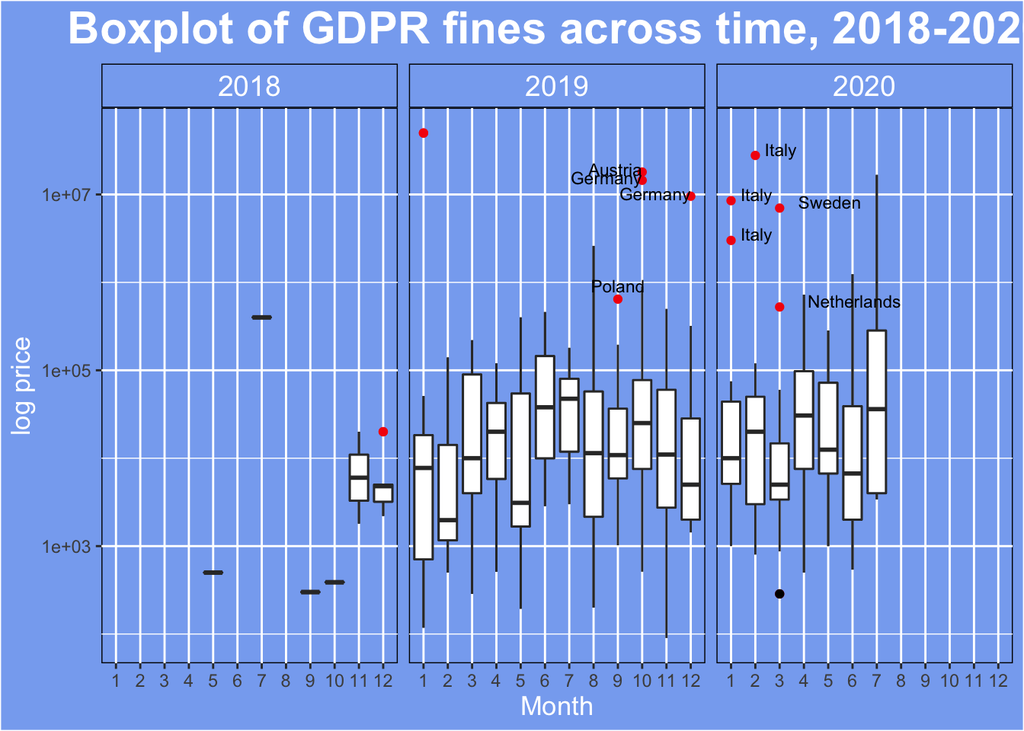

Figure 4.2: Boxplot of GDPR fines across time, 2018-2020

Box plot in Figure 4.2 looks accumulated price against time in a boxplot where median is shown. Log price was used to aid visualisation as price was an extremely skewed distribution.

The distribution of mean fines were rather staggered across the months. However, a number of outliers surfaced (circled in red) mostly at the end and start of 2019 and 2020.

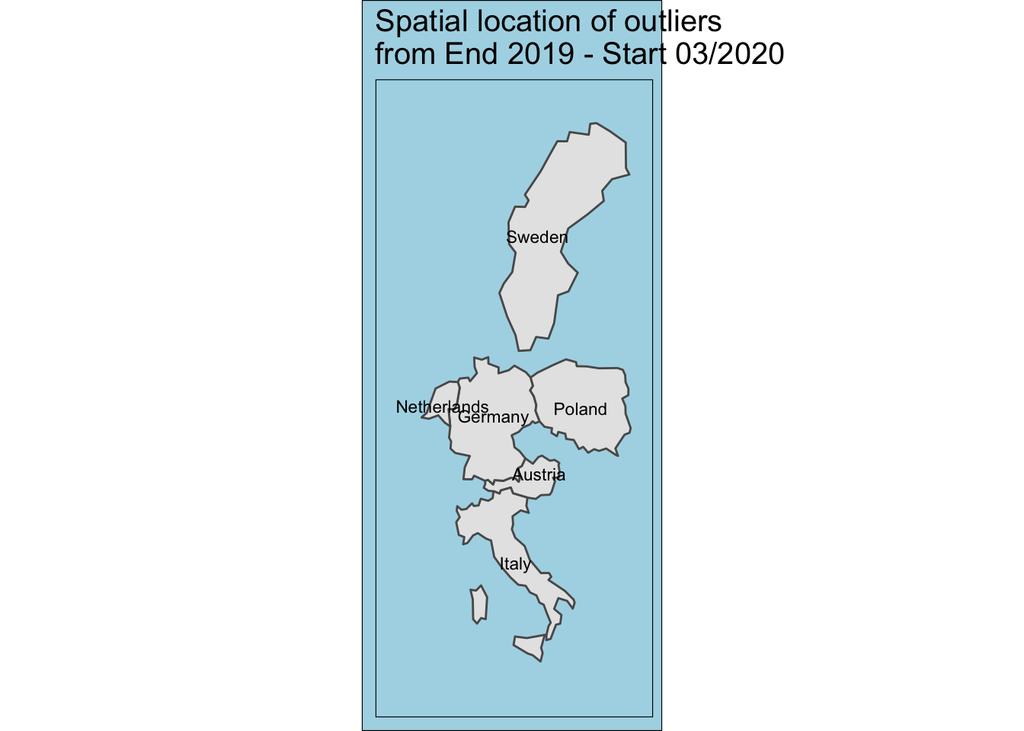

Figure 4.3: Spatial location of outliers from 09,2019 - 03,2020

These outliers include Poland, Austria, Germany, Italy, Sweden and Netherlands. Inspecting the spatial patterns of these outliers in Figure 4.3, these countries are all closely connected to one other.

### 4.1.1 Characteristics of GDPR violations across countries

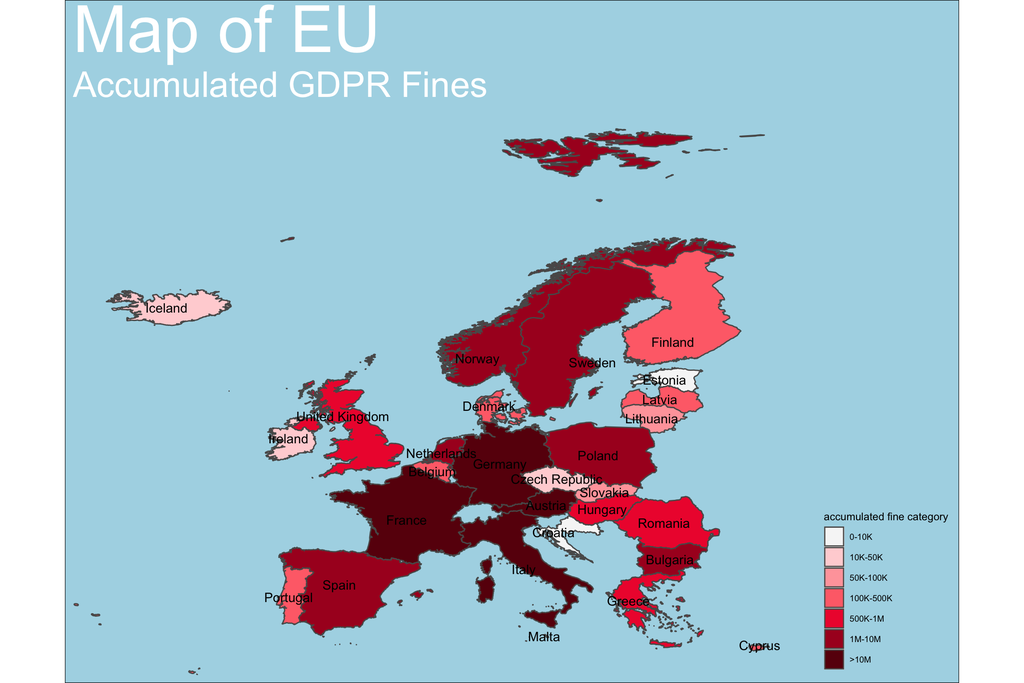

Figure 4.4: Map of GDPR Accumulated Fines

Figure 4.4 depicts the accumulated GDPR fines in EU in each price categories made.

A number of countries have fines less than €50,000 and a mix of countries in the categories upwards. Fines accumulated appear to be concentrated in the middle such as where populations are dense (e.g. France, Germany, Italy).

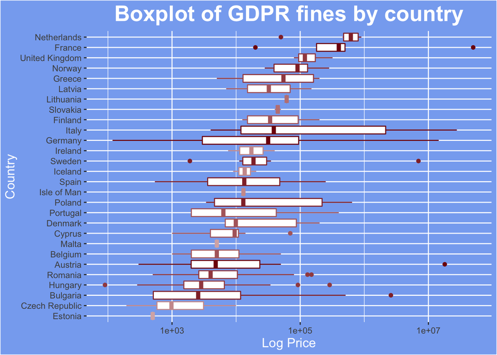

Figure 4.5: Boxplot of GDPR fines by country

Boxplot in Figure 4.5 is shaded according to the price categories in Figure 4.4. It is not necessarily that a country with the highest accumulated fines(in €) has the most number of price dished out. For example, Netherlands has €3.49M in accumulated fines but has the highest median in fine price. (refer to 4.6)

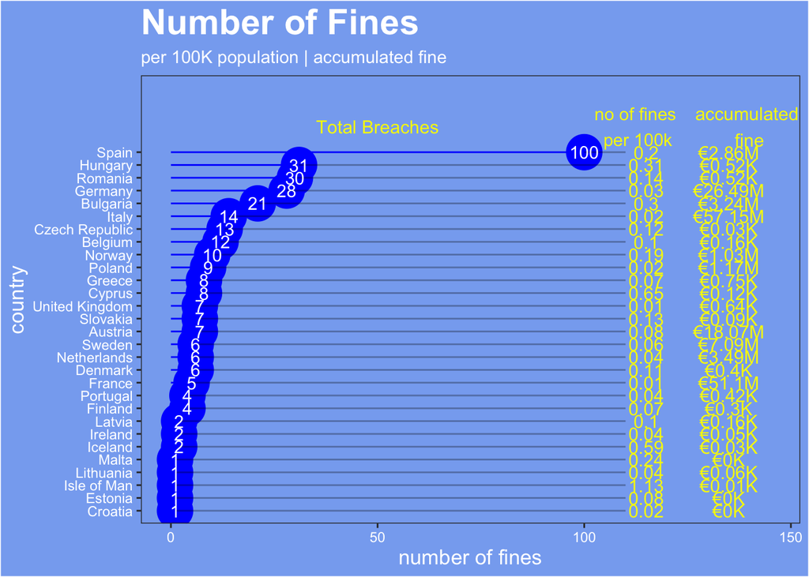

Figure 4.6: Number of GDPR violations by country, from 2018-2020

Figure 4.6 demonstrates the number of fined GDPR violations by country from 2018 to 2020. It also shows number of fines per 100,000 people in the population and accumulated fines.

Again, a disparity can be observed in the accumulated fine and number of fines. For example, in 14 fines, Italy raked up €57.15M in fine. On the other end of the spectrum. With 31 fines in Hungary, they only accumulated $0.52K in fines. In other words, authorities in some countries catch the “big fishes” while others go for volume.

All country in the EU has less than 35 cases of GDPR fines except for Spain, which has nearly 100 cases. Some exorbitant fines can be seen such as France which accumulated 51M in 5 fines.

### 4.1.2 Characteristics of GDPR violations across corporations

Was certain corporations being targeted by GDPR authorities?

Table 4.1: Largest cumulative GDPR fines by corporation

| Controller | Cumulative price | Count | Countries | Date |
| --- | --- | --- | --- | --- |
| Google | 57000000 | 2 | France, Sweden | 2019-1, 2020-3 |
| TIM - Telecom Provider | 27800000 | 1 | Italy | 2020-2 |
| Austrian Post | 18000000 | 1 | Austria | 2019-10 |
| Wind Tre S.p.A. | 16700000 | 1 | Italy | 2020-7 |
| Deutsche Wohnen SE | 14500000 | 2 | Germany | 2019-10 |
| Eni Gas e Luce | 11500000 | 2 | Italy | 2020-1 |
| 1&1 Telecom GmbH | 9550000 | 1 | Germany | 2019-12 |
| National Revenue Agency | 2628100 | 2 | Bulgaria | 2019-8, 2019-9 |
| Allgemeine Ortskrankenkasse | 1240000 | 1 | Germany | 2020-6 |
| Vodafone España | 918000 | 19 | Spain | 2019-3, 2019-4, 2019-6, 2019-10, 2019-11, 2020-1, 2020-2, 2020-3 |

Note:  
Companies with background in red are owned by corporations or individuals outside EU

Table 4.1 shows us the information about the ten corporations that have accumulated the most fines since the introduction of GDPR. Notice that only three of them are non-local corporations, which suggests we can not reject the hypothesis of a multinational corporation is being fairly treated by GDPR.

Google was fined 2 times and had to pay a fortune of 57 million euros. It is worth notice that Vodafone España was fined 19 times, the highest number of financial penalties received. A closer look at the British telecommunication company is provided in table 4.2. We discovered another fact: Not only did Vodafone España receive a very high number of fines, its branch, Vodafone ONO also receive 2 fines. Together, Vodafone violated the GDPR 21 times in Spain, which is a fifth of the country’s total number of violations.

> Most of the violating companies; were large companies; especially with large amount of data.

Table 4.2: GDPR fines issued to Vodafone

| Controller | Countries | Cumulative_price | Count | Date |
| --- | --- | --- | --- | --- |
| Vodafone España | Spain | 918000 | 19 | 2019-10, 2019-4, 2019-6, 2019-3, 2019-11, 2020-1, 2020-2, 2020-3 |
| Vodafone ONO | Spain | 96000 | 2 | 2019-6, 2020-2 |
| Vodafone Romania | Romania | 7150 | 2 | 2020-2, 2020-3 |

## 4.2 Analysis of violated article

In this part, the researchers want to find out: Which articles and regulations were more likely to be violated? And how much they commonly charged?

Figure 4.7 answer the first question. Article 5 - “Principles relating to the processing of personal data”, Article 6 - “Lawfulness of processing” and Article 32 - “Security of processing” are most likely to get violated by controllers. More than half of all violations are related to these three articles. It indicates that the “Processing” of personal data in the EU has issues, which lead to a high number of violations. Further research could explore these issues and provide more detail and clearer view.

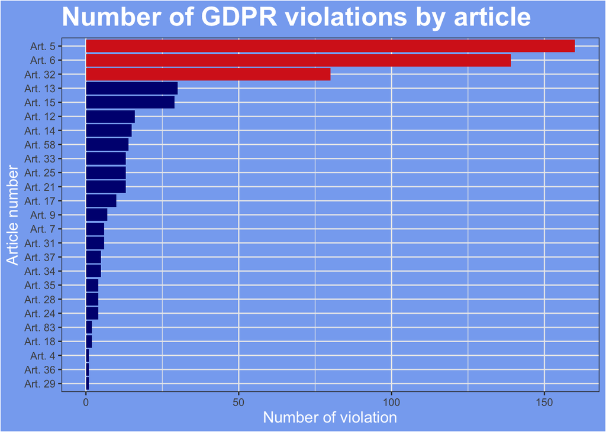

Figure 4.7: Number of violations by GDPR articles

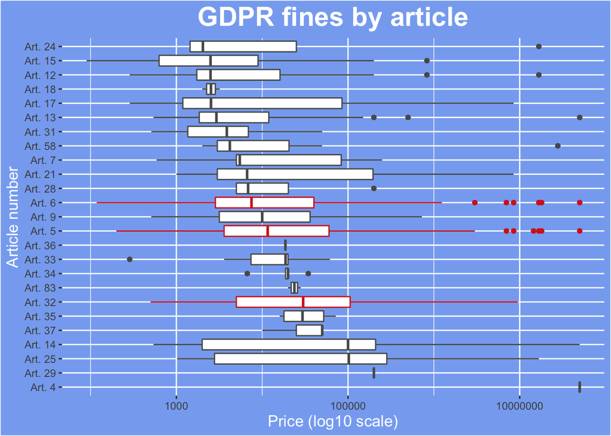

Figure 4.8: GDPR fines by article

## 4.3 Text mining GDPR articles

In this part, the researchers want to find out: What were the keywords in each article, especially articles referenced the most in GDPR fines? How did it reflect the privacy issues in the EU?

### 4.3.1 Overview of words in GDPR articles

Figure 4.9 reflects the key concerns in GDPR. From the word cloud, we can see some regular words related to law such as “article”, “regulation”, “paragraph” and “pursuant”. We can also find words related to data governance, like “processing”, “processor”, “authority”, “supervisory” and “commission”. It seems like the GDPR provides a framework to govern the general data usage within the EU and empower some authorities to supervise companies. More importantly, words are explaining the spirit of GDPR, which are “freedom”, “personal”, “rights” and “public”. It tells us GDPR concerns about personal and public freedom. Besides, we feel surprised that “privacy” is not a keyword in GDPR.

[interactive chart not shown]

Figure 4.9: Word cloud of GDPR

### 4.3.2 Words in Article 5, 6 and 32 respectively

In Table 4.3, some words repeatedly occur. They are “data”, “process”, “personal” and “controller”. It suggests the most common privacy issue in the EU is illegal processing of personal data. We can also find the most different words are “access” in Article 32, “subject” in Article 6 and “purposes” and “manner” in Article 5. It reflects slightly different core topics in these 3 articles. Other than that, they are very similar overall.

Table 4.3: Top 5 most common words for article 5, 6 and 32 respectively

| article | word | count |
| --- | --- | --- |
| 5 | purposes | 12 |
| 5 | data | 10 |
| 5 | processed | 7 |
| 5 | personal | 6 |
| 5 | manner | 3 |
| 6 | processing | 25 |
| 6 | data | 21 |
| 6 | personal | 10 |
| 6 | subject | 9 |
| 6 | controller | 8 |
| 32 | controller | 4 |
| 32 | data | 4 |
| 32 | personal | 4 |
| 32 | processing | 4 |
| 32 | access | 3 |

### 4.3.3 Overview of trigrams in GDPR articles

[interactive chart not shown]

Trigram analysis can often provide us with more useful information about a text document. Figure 4.10 provides us with very special “GDPR” words. We can see “data protection officer”, which is probably the officer work for the authority, and “competent supervisory authority”, which is probably referring to the data protection authority.

Notice that there are a term “binding corporate rules”, this represents multinational corporations are allowed to transfer personal data in an intra-organizational manner. This rule increases the risk of a potential leak of personal data on other nations outside the EU.

Ignore these highly complicated article phrases, we can still find some interesting terms which we are familiar with. Like the one “historical research purpose”. It suggests data analysis is under consideration of GDPR.

[interactive chart not shown]

Figure 4.10: Word cloud of trigram in GDPR

## 4.5 Findings

Regarding to the General Data Protection Regulation, the report discovers that the most commonly violated GDPR’s article are article 5, article 6 and article 32, All of which focused on the “Processing” of personal data. It indicates that the “Processing” of personal data in EU may have issues.

From this report, future research could consider focusing on the case of Spain and Vodafone Espana. The British telecommunication corporation received a fifth of the total financial penalties related to GDPR violations in Spain. The Spain authorities have their eyes set on Vodafone.

Another research field that can be focused on is the issues in the “Processing” of personal data in EU. As the most commonly violated GDPR’s article are all related to Processing of personal data, there seems to be issues in this field.

# 5 Conclusion

GDPR is one of the most widely touted regulation for personal data protection. From the characteristics of fines given out in countries in 4.1.1, there is a disparity in implementation - some countries catch the “big fishes” while some go for volumes. Most of the fines occur at the end the end of the year and first few months of a new year.

Besides, no such evidence supports that GDPR was generally used as an alternative to “digital service tax” against multinational corporations. However, one particular corporation, Vodafone, was a target of the Spanish Data Protection Authority multiple times, which might be a special case. Moreover, the GDPR fines revealed that the most serious privacy issue in EU is the processing of personal data.

With the regulation still in its novelty stage, it would be interesting to follow where it goes from here.

# 6 Acknowledgement

Following R packages are used in producing this research:  
- colorspace: Zeileis et al. (2019)  
- rmarkdown: Xie, Allaire, & Grolemund (2018)  
- tidyverse: Wickham et al. (2019)  
- kableExtra: Zhu (2019)  
- ggplot2: Wickham (2016)  
- plotly: Sievert (2020)  
- bookdown: Xie (2016)  
- wordcloud2: Lang & Chien (2018)  
- lubridate: Grolemund & Wickham (2011)  
- tidytext: Silge & Robinson (2016)  
- rnaturalearth: South (2017)  
- sf: Pebesma (2018) - DT Xie, Cheng, & Tan (2020)  
- widgetframes Karambelkar (2017)  
- Htmlwidgets Vaidyanathan, Xie, Allaire, Cheng, & Russell (2019)

# References

CoreView. (2020). *Major gdpr fine tracker*. https://www.coreview.com/blog/alpin-gdpr-fines-list/.

Ellis Hughes. (2020). *Thebioengineer*. https://github.com/thebioengineer.

Grolemund, G., & Wickham, H. (2011). Dates and times made easy with lubridate. *Journal of Statistical Software*, *40*(3), 1–25. Retrieved from http://www.jstatsoft.org/v40/i03/

Karambelkar, B. (2017). *Widgetframe: ’Htmlwidgets’ in responsive ’iframes’*. Retrieved from https://CRAN.R-project.org/package=widgetframe

Lang, D., & Chien, G.-t. (2018). *Wordcloud2: Create word cloud by ’htmlwidget’*. Retrieved from https://CRAN.R-project.org/package=wordcloud2

Lewis, J. A., Conleya, H. A., & Lee-Makiyama, H. (2020). *Has europe lost both the battle and war over its digital future?* https://www.csis.org/analysis/has-europe-lost-both-battle-and-war-over-its-digital-future.

Pebesma, E. (2018). Simple Features for R: Standardized Support for Spatial Vector Data. *The R Journal*, *10*(1), 439–446. https://doi.org/10.32614/RJ-2018-009

Porter, J. (2020). *Google fined €50 million for gdpr violation in france*. https://www.theverge.com/2019/1/21/18191591/google-gdpr-fine-50-million-euros-data-consent-cnil.

Privacy Affairs. (2020). *GDPR fines tracker & statistics*. https://www.privacyaffairs.com/gdpr-fines/.

Regulation, G. D. P. (2016). Regulation (eu) 2016/679 of the european parliament and of the council of 27 april 2016 on the protection of natural persons with regard to the processing of personal data and on the free movement of such data, and repealing directive 95/46. *Official Journal of the European Union (OJ)*, *59*(1-88), 294.

Sievert, C. (2020). *Interactive web-based data visualization with r, plotly, and shiny*. Chapman; Hall/CRC. Retrieved from https://plotly-r.com

Silge, J., & Robinson, D. (2016). Tidytext: Text mining and analysis using tidy data principles in r. *JOSS*, *1*(3). https://doi.org/10.21105/joss.00037

South, A. (2017). *Rnaturalearth: World map data from natural earth*. Retrieved from https://CRAN.R-project.org/package=rnaturalearth

Tidy Tuesday. (2020). *A weekly social data project in r*. https://github.com/rfordatascience/tidytuesday.

Tikkinen-Piri, C., Rohunen, A., & Markkula, J. (2018). EU general data protection regulation: Changes and implications for personal data collecting companies. *Computer Law & Security Review*, *34*(1), 134–153.

Vaidyanathan, R., Xie, Y., Allaire, J., Cheng, J., & Russell, K. (2019). *Htmlwidgets: HTML widgets for r*. Retrieved from https://CRAN.R-project.org/package=htmlwidgets

Wickham, H. (2016). *Ggplot2: Elegant graphics for data analysis*. Springer-Verlag New York. Retrieved from https://ggplot2.tidyverse.org

Wickham, H., Averick, M., Bryan, J., Chang, W., McGowan, L. D., François, R., … Yutani, H. (2019). Welcome to the tidyverse. *Journal of Open Source Software*, *4*(43), 1686. https://doi.org/10.21105/joss.01686

Xie, Y. (2016). *Bookdown: Authoring books and technical documents with R markdown*. Boca Raton, Florida: Chapman; Hall/CRC. Retrieved from https://github.com/rstudio/bookdown

Xie, Y., Allaire, J. J., & Grolemund, G. (2018). *R markdown: The definitive guide*. Boca Raton, Florida: Chapman; Hall/CRC. Retrieved from https://bookdown.org/yihui/rmarkdown

Xie, Y., Cheng, J., & Tan, X. (2020). *DT: A wrapper of the javascript library ’datatables’*. Retrieved from https://CRAN.R-project.org/package=DT

Zeileis, A., Fisher, J. C., Hornik, K., Ihaka, R., McWhite, C. D., Murrell, P., … Wilke, C. O. (2019). *colorspace: A toolbox for manipulating and assessing colors and palettes* (arXiv No. 1903.06490). arXiv.org E-Print Archive. Retrieved from arXiv.org E-Print Archive website: http://arxiv.org/abs/1903.06490

Zhu, H. (2019). *KableExtra: Construct complex table with ’kable’ and pipe syntax*. Retrieved from https://CRAN.R-project.org/package=kableExtra